# Exploration of OpenStreetMap Data

- Introduction
- Overview
- Preparing for a MongoDB Database
- Exploration Using MongoDB
- Conclusions and Other Ideas About the Dataset

## Introduction

OpenStreetMap is a map of the world, free to use under an open license.

For this exploration, data corresponding to area around San Francisco, CA is examined. Said data was obtained through Metro Extracts, which consist of data corresponding to "the rectangular region surrounding a particular city or region of interest." In particular, the data was obtained [at this web address](https://mapzen.com/data/metro-extracts/metro/san-francisco-bay_california/) and corresponds to the following:

[figure not shown]

We'll begin with a brief overview of the data. We'll look at the amount of data and the content of the dataset.

We'll then prepare the dataset for a MongoDB database, load it into such a database, and examine the dataset for notable information.

## Overview

Let's begin with a brief overview of the data.

Before importing any libraries, we must first append to the list of paths in which to look for libraries.

```python
import sys
sys.path.append('/home/jonj/miniconda3/lib/python3.6/site-packages')
```

```python
import os
import numpy as np
import xml.etree.cElementTree as ET
import pprint
import re
from collections import defaultdict
import codecs
import json
from pymongo import MongoClient
import matplotlib.pyplot as plt
import seaborn as sns
import pandas as pd
from scipy.cluster.vq import kmeans2, whiten
```

```python
print('{:.1f} MB'.format(os.path.getsize('san-francisco_california.osm.bz2') * 1e-6))
```

```
88.6 MB
```

```python
print('{:.3f} GB'.format(os.path.getsize('san-francisco_california.osm') * 1e-9))
```

```
1.414 GB
```

First, we see that the size of the uncompressed data is approximately 1.414 GB, relative to the compressed size of appproximately 88.6 MB.

```python
OSM_FILE = 'san-francisco_california.osm'
```

Now we'll perform a superficial overview of the content we have. We'll use iterative parsing because the data seems too large to fit into my memory limits.

```python
# Create a dictionary of tags
tags = {}

# Count the number of elements with each tag
for _, elem in ET.iterparse(OSM_FILE):
    tag = elem.tag
    if tag in tags:
        tags[tag] += 1
    else:
        tags[tag] = 1
```

```python
tags
```

```
{'bounds': 1,
 'member': 64135,
 'nd': 7885078,
 'node': 6641035,
 'osm': 1,
 'relation': 8023,
 'tag': 2069587,
 'way': 827729}
```

As found above, the consequential tags are member, nd, node, relation, tag, way. The tags bounds and osm only occur once so these probably are specific to the dataset but not important for loading the data into a database. We already know that the element with the "osm" tag merely identifies the details of the data retrieval and is of no significance for our present purposes. With regard to the other element, though, we don't want to be too quick to dismiss it, though, so let's examine the corresponding line in more detail.

```python
with open(OSM_FILE, 'r') as f:
    for line in f:
        # The tag is contained in the first token of each entry
        tag = line.strip().split()[0]
        if 'bounds' in tag:
            # If the string 'bounds' is in our tag, we've found our line.
            #  Print it and exit
            print(line)
            break
```

```
	<bounds minlat="37.449" minlon="-122.737" maxlat="37.955" maxlon="-122.011"/>
```

As surmised, the line doesn't appear important. The element with the 'bounds' tag merely tells us the geographical coordinates that bound the data.

```python
total = 0
for key in tags:
    total += tags[key]

print(total)
```

```
17495589
```

We see that we have approximately 17.5 million lines of data. Approximately 6.6 million of those lines correspond to nodes (i.e., geographical points, such as for point features and for points along a way) whereas approximately 828,000 of those lines correspond to ways (i.e., polylines, such as for rivers, roads, and boundaries; a way can be defined by multiple nodes).

## Preparing for a MongoDB Database

We'll now prepare the dataset for a MongoDB database. We must:

- address potentially mispelled street types (e.g., if the same concept is spelled different ways, we won't see that the different results refer to the same concept)
- convert our XML file to JSON, as MongoDB databases don't "understand" the former. During this process, we'll address data that cannot be included in the database</a>

Let's begin with mispelled data. The most obvious issue is that of street names. Some may abbreviate street names, with or without punctuation, whereas others may not. Thus, we may have:

- Market Street
- Market St.
- Market St,
- Market St
- and etc.

These may all refer to the same entity but if we regard different names as referring to different entities, we will end up thinking that there are several different and less prominent entities when there is in fact, a single, relatively prominent entity.

Let's address that issue. Our first step is to create a dictionary containing as keys all alternate spellings of a name. At first glance, possible names should be:

- Street,
- Avenue,
- Boulevard,
- Drive,
- Court,
- Place,
- Square,
- Lane,
- Road,
- Trail,
- Parkway, and
- Commons

We'll put all of those names in a list, `expected` and compile a regular expression object to match the last token in a string since we expect street names to end with a road name, as in `expected` and to possibly be followed by a period (e.g., if abbreviated or at the end of a sentence). Since capitalization differences may occur, we must stipulate that the case of words not be considered. To get a list of all alternative spellings of street names, we'll take the final token, using the regular expression object, of each street name. If that name is not in our list of expected street names, we'll add the particular value (i.e., entire street name) to a dictionary called `street_types`. The keys of the dictionary will be all street types (e.g., St., Ave., Blvd.) and the values will be all of the corresponding entire street names.

```python
expected = ["Circle", "Way", "Terrace", "Street",
            "Avenue", "Boulevard", "Drive", "Court",
            "Place", "Square", "Lane", "Road", "Trail",
            "Parkway", "Commons"]

street_type_re = re.compile(r'\b\S+\.?$', re.IGNORECASE)

numbers = [str(i) for i in range(10)]

def audit_street_type(street_types, street_name):
    # This function takes the street type (final token of the string) and
    #  checks to see if it's in our list of expected street types. If not,
    #  the street name will be added to our street_types dictionary
    m = street_type_re.search(street_name)
    if m:
        street_type = m.group()

        # We don't want numbers, as numbers may refer to a suite number
        #  or another detail that does not indicate a street type.
        if street_type not in expected and street_type[-1] not in numbers:
            street_types[street_type].add(street_name)

def is_street_name(elem):
    # This function checks to see whether the input element refers to a street.
    #  If so, its value for the 'k' attribute will be "addr:street"
    return (elem.attrib['k'] == "addr:street")

def audit(osmfile):
    with open(osmfile, "r") as osm_file:
        street_types = defaultdict(set)

        # Again, we'll use iterative parsing, as there seems too much
        #  data for my memory limits
        for event, elem in ET.iterparse(osm_file, events=("start",)):

            # Streets are only referred to in nodes and ways.
            #  We can ignore all elements with other tags
            if elem.tag == "node" or elem.tag == "way":
                for tag in elem.iter("tag"):

                    # If the element is a street name, audit the type.
                    if is_street_name(tag):
                        audit_street_type(street_types, tag.attrib['v'])

    return street_types

street_types = audit(OSM_FILE)
```

```python
pprint.pprint(street_types)
```

```
defaultdict(<class 'set'>,
            {'122°29\'07.1"W': {'37°42\'46.0"N 122°29\'07.1"W'},
             '15th': {'15th'},
             'A': {'Upton St #A', 'Adrian Court, Suite A'},
             'AVE': {'MILLSBRAE AVE'},
             'Airport': {'San Francisco Internation Airport'},
             'Alameda': {'The Alameda', 'Alameda'},
             'Alhambra': {'Avenue Alhambra'},
             'Alley': {'August Alley',
                       'Hodges Alley',
                       "Kahn's Alley",
                       'Lilac Alley',
                       'Redfield Alley',
                       'Ross Alley'},
             'Alto': {'Camino Alto'},
             'Arguello': {'Arguello'},
             'Ashfield': {'Ashfield'},
             'Ave': {'Bayshore Ave',
                     'Blenheim Ave',
                     'California Ave',
                     'Cherry Ave',
                     'Corte Madera Ave',
                     'Crescent Ave',
                     'Day Ave',
                     'E 28th Ave',
                     'Eagle Ave',
                     'Earl Ave',
                     'Esplanade Ave',
                     'Floribunda Ave',
                     'Geneva Ave',
                     'Grant Ave',
                     'Greenwood Ave',
                     'Huntington Ave',
                     'Hurlingame Ave',
                     'Jerrold Ave',
                     'Loma Vista Ave',
                     'Lorton Ave',
                     'Magnolia Ave',
                     'McBryde Ave',
                     'Morena Ave',
```

[output cut: 256 more lines]

```
             'West': {'Buena Vista Avenue West',
                      'Embarcadero West',
                      'Industrial Parkway West'},
             'Wharf': {'Fishermans Wharf'},
             'Yolanda': {'Corte Yolanda'},
             'arrowhead': {'lake arrowhead'},
             'avenue': {'Santa Cruz avenue'},
             'blvd': {'foothill blvd'},
             'broadway': {'broadway'},
             'c': {'Hough Ave c'},
             'parkway': {'Bridge parkway'},
             'square': {'33 union square'},
             'st': {'Kearny st', 'Crane st'},
             'street': {'Vallejo street'},
             'way': {'Orinda way'}})
```

It seems we must use all of the following alternative spellings when altering street names to account for mispellings and alternative spellings:

- Ave
- Ave.
- Blvd
- Blvd.
- Dr
- Pl
- Rd
- Rd.
- St
- St.

It also seems we must consider capitalization issues (e.g., by using the title() method of strings in Python), as "St" and "st" presumably refer to the same street type, though may not if we consider capitalization to be indicative of distinctness. This will preclude consideration of street types that are distinguished by capitalization, though.

In addition, readily apparent are street names that refer to more than a single name, such as 'W & E Of Us 101 N Of Seminary Ave'. It would be simple to omit these - merely stipulate that addresses with a value for len(street_name.split(' ')) that is greater than five should not be added. Most of the unconventional addresses are unique, and there are not many such instances, as is shown below. It seems reasonable to include other aspects of such entities (e.g., geographical coordinates) and not such addresses.

```python
# First, we create a list of all street names in the file. We can use
#  the previous code to iteratively parse the file and extract street names

with open(OSM_FILE, "r") as osm_file:
    street_names = []

    # Again, we'll use iterative parsing, as there seems
    #  too much data for my memory limits
    for event, elem in ET.iterparse(osm_file, events=("start",)):

        # Streets are only referred to in nodes and ways.
        #  We can ignore all elements with other tags
        if elem.tag == "node" or elem.tag == "way":
            for tag in elem.iter("tag"):

                # If the element is a street name, audit the type.
                if is_street_name(tag):
                    street_names.append(tag.attrib['v'])

# Next, we'll count the number of probably invalid street names, defined as
#  those containing more than five tokens separated by spaces (e.g.,
#  'Ne Quad I-280 / Edgewood Rd Ic' is not a conventional street address
#  whereas 'Martin Luther King Junior Way' is a conventional street address).
# We'll do this by splitting each street address and checking if its length exceeds 5
count = 0
for s in street_names:
    if len(s.split())>5:
        count += 1
        print(s)
print('\ncount: {}'.format(count))
```

```
Ne Quad I-280 / Edgewood Rd Ic
012 Mi Ne Of Sr 1 / Linda Mar Blvd Int
Nw Quad Sr 84 / Ardenwood Blvd Ic
Under Ramp Sw Quad Of Us 101 / Sr 92 Ic Off 19th Ave & Fashion Island Blvd
Se Quad Sr 92 / Ralston Ic
Nw Quad I-280 / Sr 35 Ic @ Jct Hayne Rd, Golf Course Dr, Skyline Blvd,
Ne Quad Us 101 / 3rd Ave Off Lindbergh
Sawyer Camp Trail & Hillcrest Blvd
E Of Center St @ I-580
N Side Of Foothill Blvd @ John Dr (Near I-580)
E & W Of  Us 101 @ Monte Mar & Spencer
Under I-880 @ 7th St & Linden St
Under I-580 Btwn Fruitvale / Champion St
Under I-580 Btwn Fruitvale / Champion St
W Of Us 101 @ Jct Sr 1
W & E Of Us 101 N Of Seminary Ave
W & E Of Us 101 N Of Seminary Ave
Se Quad I-680 / Rudgear Rd
North Wiget Lane & North Wiget Drive

count: 19
```

```python
print('About {:.5f}% of the addresses are not conventional'.format(
    count/len(street_names)))
```

```
About 0.00032% of the addresses are not conventional
```

Before we go any further, let's verify that our strategies to address alternate spellings and to address unconventional street names works. We'll test our strategies on data drawn from the dataset, rather than contrived examples.

```python
# Let's first create a mapping dictionary according to what we found previously
mapping = { 'Ave'       : 'Avenue',
            'Ave.'      : 'Avenue',
            'Avenue'    : 'Avenue',
            'Blvd'      : 'Boulevard',
            'Blvd.'     : 'Boulevard',
            'Boulevard' : 'Boulevard',
            'Dr'        : 'Drive',
            'Drive'     : 'Drive',
            'Pl'        : 'Place',
            'Place'     : 'Place',
            'Rd'        : 'Road',
            'Rd.'       : 'Road',
            'Road'      : 'Road',
            'St'        : 'Street',
            'St.'       : 'Street',
            'Street'    : 'Street',
          }

# We'll need to redefine some of our functions to work with mapping
#  and to return our alterations
def audit_street_type(orig_street_list, updated_street_list, street_name):
    # This function takes the street type (final token of the string) and checks
    #  to see if it's in our list of expected street types. If not, the street name
    #  will be added to our list of street names
    m = street_type_re.search(street_name)
    if m:
        street_type = m.group()
        if street_type in mapping:
            orig_street_list.append(street_name)
            updated_street_list.append(update_name(street_name, mapping, street_type))

def audit(osmfile):
    orig_street_list, updated_street_list = [], []

    # For the sake of readability, we don't want to print too many names.
    #  Let's limit the total number of long street names (more than 5 tokens) to 3
    numLeft = 3
    for street_name in street_names:
        if not numLeft:
            break
        if len(street_name.split()) > 5:
            orig_street_list.append(street_name)
            updated_street_list.append('')
            numLeft -= 1
        elif len(orig_street_list) < 10:
            audit_street_type(orig_street_list, updated_street_list, street_name)
    return orig_street_list, updated_street_list

def update_name(name, mapping, street_type):
    return name.replace(street_type, mapping[street_type])

# Use the redefined functions and print the results
orig_street_list, updated_street_list = audit(OSM_FILE)

for i in range(len(orig_street_list)):
    print('-------------------')
    print(' original: {}'.format(orig_street_list[i]))
    print(' updated:  {}'.format(updated_street_list[i]))
    print('-------------------')
```

```
-------------------
 original: Haight Street
 updated:  Haight Street
-------------------
-------------------
 original: Haight Street
 updated:  Haight Street
-------------------
-------------------
 original: Haight Street
 updated:  Haight Street
-------------------
-------------------
 original: Haight Street
 updated:  Haight Street
-------------------
-------------------
 original: Haight Street
 updated:  Haight Street
-------------------
-------------------
 original: Divisadero Street
 updated:  Divisadero Street
-------------------
-------------------
 original: Valencia Street
 updated:  Valencia Street
-------------------
-------------------
 original: Haight Street
 updated:  Haight Street
-------------------
-------------------
 original: Haight Street
 updated:  Haight Street
-------------------
-------------------
 original: Haight Street
 updated:  Haight Street
-------------------
-------------------
 original: Ne Quad I-280 / Edgewood Rd Ic
 updated:
-------------------
-------------------
 original: 012 Mi Ne Of Sr 1 / Linda Mar Blvd Int
 updated:
-------------------
-------------------
 original: Nw Quad Sr 84 / Ardenwood Blvd Ic
 updated:
-------------------
```

It looks like it's working. Great! Let's move on to the next step in preparation

Now, we'll convert our file from the XML format to JSON. In the process, we'll match misspellings and alternative spellings of street types and removing invalid street addresses. We'll also make sure not to include any keys containing problematic characters for MongoDB.

First, we'll compile `problemchars` as a regular expression object that will match all characters that can't be used in keys in a MongoDB database.

```python
problemchars = re.compile(r'[=\+/&<>;\'"\?%#$@\,\. \t\r\n]')
```

We want our file entries in the equivalent of the following format (JSON):

```
{
"id": "2406124091",
"type: "node",
"visible":"true",
"created": {
          "version":"2",
          "changeset":"17206049",
          "timestamp":"2013-08-03T16:43:42Z",
          "user":"linuxUser16",
          "uid":"1219059"
        },
"pos": [41.9757030, -87.6921867],
"address": {
          "housenumber": "5157",
          "postcode": "60625",
          "street": "North Lincoln Ave"
        },
"amenity": "restaurant",
"cuisine": "mexican",
"name": "La Cabana De Don Luis",
"phone": "1 (773)-271-5176"
}
```

In particular we'll do the following:

- process only 2 types of top level tags: "node" and "way"
- change all attributes of "node" and "way" into regular key/value pairs, except:
  - add attributes in the CREATED array under a key "created"
  - add attributes for latitude and longitude as floats to a "pos" array,
- if the second level tag "k" value contains problematic characters, ignore it
- if the second level tag "k" value starts with "addr:", add it to a dictionary "address"
- if the second level tag "k" value does not start with "addr:", but contains ":", it is split into a two-level dictionary like with "addr:"
- if there is a second ":" that separates the type/direction of a street, ignore the tag

Before we begin, though, there is a slight problem. In the dataset, there are some tags with a k value equivalent to some capitalization of 'address' instead of or in addition to tag(s) with k values of addr:X where X = street, housenumber, etc. The following shows these entries.

```python
for _, element in ET.iterparse(OSM_FILE):
    if element.tag == "node" or element.tag == "way":
        for tag in element.iter('tag'):
            if tag.tag == 'tag':
                if tag.attrib['k'].lower() == 'address':
                    print(tag.attrib['v'])
```

```
400 Valencia Street
1115 Solano Avenue
421 40th Street
220 Middlefield Drive
3692 18th Street
1748 Church Street
3054 Taraval Street
1304 Lincoln Avenue
1396 La Playa Street
4184 Piedmont Avenue
2760 24th Street
2832 Mission Street
400 40th Street
846 Divisadero Street
1175 Solano Ave
```

[output cut: 43 more lines]

If the length of the v attribute of said tags is greater than 1 token, it is a valid address, with the first token being the housenumber and the next tokens constituting the street name. Otherwise, we have no use for the v attribute (e.g., 27 is not a valid address. We are not even sure if it is a housenumber).

Let's move on, then, keeping this in mind. We'll reshape each element to conform to the JSON format and use our code above to correct mispellings and omit irrelevant information.

```python
CREATED = [ "version", "changeset", "timestamp", "user", "uid"]

def shape_element(element):

    if element.tag == "node" or element.tag == "way" :
        # Each element will be represented as a dictionary with 'id' and 'type' keys
        #  and a dictionary of information about when the entry was created
        node = {
            'id'      : element.attrib['id'],
            'type'    : element.tag,
            'created' : {}
        }

        # Add the information about when the entry was created
        for attr in CREATED:
            if attr in element.attrib:
                node['created'][attr] = element.attrib[attr]

        # Add the position information accordingly
        if 'lat' in element.attrib:
            node['pos'] = [float(element.attrib['lat']), float(element.attrib['lon'])]

        # Make a list of other information to add. We've already added
        #  information about the entry creation and position, so remove
        #  those from the list
        attribs = list(element.attrib)
        for i in CREATED:
            if i in attribs:
                attribs.remove(i)
        if 'lat' in attribs:
            attribs.remove('lat')
            attribs.remove('lon')

        # Add the information we haven't yet added
        for attr in attribs:
            node[attr] = element.attrib[attr]

        # Now add information from second level elements. Regardless of the type
        #  of the top  level element, we'll want to add information from second
        #  level elements with the tag 'tag'.
        for tag in element.iter('tag'):
            if tag.tag == 'tag':
                k = tag.attrib['k']

                # If the k value is problematic, skip it. If it begins with addr:,
                #  assume it only consists of two "levels" and proceed accordingly.
                #  Otherwise, if it consists of two other levels, add the information
                #  accordingly. If it consists of more than two "levels", skip it.
                #  In every other case, add the information straightforwardly
                if re.search(problemchars, k):
                    continue

                elif k[:5] == 'addr:':
                    if ':' not in k[5:]:
                        if 'address' not in node:
                            node['address'] = {}
                        k_split = k.split(':')
                        name = tag.attrib['v'].title()
                        if k_split[1] == 'street':
                            m = street_type_re.search(name)
                            if m:
                                street_type = m.group()
                                if street_type in mapping:
                                    if len(name.split()) <= 5:
                                        name = name.replace(street_type, mapping[street_type])
                        node['address'][k_split[1].lower()] = name

                elif ':' in k:
                    k_split = k.split(':')
                    if len(k_split) > 2:
                        continue
                    node[k_split[0].lower()] = k_split[1].title()

                else:
                    if k.lower() != 'address':
                        node[k.lower()] = tag.attrib['v']
                    else:
                        split_address = tag.attrib['v'].split()
                        if len(split_address) == 1:
                            continue

                        node['address'] = {}
                        node['address']['housenumber'] = split_address[0]
                        node['address']['street'] = ' '.join(split_address[1:])

        # If the top level element is a way, we'll add information from second level
        #  elements with the tag 'nd'
        if element.tag == 'way':
            node['node_refs'] = []
            for tag in element.iter('nd'):
                node['node_refs'].append(tag.attrib['ref'])

        # Finally, return the result
        return node

    else:
        # If the top level tag is neitner 'node' nor 'way', do nothing
        return None


data = []
with codecs.open('OSM_FILE.json', "w") as fo:
    for _, element in ET.iterparse(OSM_FILE):
        el = shape_element(element)
        if el:
            data.append(el)
            fo.write(json.dumps(el, indent=2) + "\n")
```

Let's take a look at our resulting data file.

```python
JSON_FILE = 'OSM_FILE.json'

with open(JSON_FILE) as f:
    i = 50
    for line in f:
        if not i:
            break
        pprint.pprint(line)
        i -= 1
```

```
'{\n'
'  "id": "281266",\n'
'  "type": "node",\n'
'  "created": {\n'
'    "version": "7",\n'
'    "changeset": "50739891",\n'
'    "timestamp": "2017-08-01T06:46:51Z",\n'
'    "user": "muziriana",\n'
'    "uid": "6058023"\n'
'  },\n'
'  "pos": [\n'
'    37.5601845,\n'
'    -122.3025783\n'
'  ],\n'
'  "highway": "motorway_junction",\n'
'  "ref": "414B"\n'
'}\n'
'{\n'
'  "id": "281393",\n'
'  "type": "node",\n'
'  "created": {\n'
'    "version": "8",\n'
'    "changeset": "3061377",\n'
'    "timestamp": "2009-11-08T08:11:05Z",\n'
'    "user": "StellanL",\n'
'    "uid": "28775"\n'
'  },\n'
'  "pos": [\n'
'    37.5280244,\n'
'    -122.2948711\n'
'  ]\n'
'}\n'
'{\n'
'  "id": "281394",\n'
'  "type": "node",\n'
'  "created": {\n'
'    "version": "7",\n'
'    "changeset": "3061377",\n'
'    "timestamp": "2009-11-08T08:11:05Z",\n'
'    "user": "StellanL",\n'
'    "uid": "28775"\n'
'  },\n'
'  "pos": [\n'
'    37.5271055,\n'
'    -122.2978408\n'
'  ]\n'
'}\n'
'{\n'
'  "id": "281395",\n'
'  "type": "node",\n'
```

The first few elements don't illustrate street addresses so let's print a subset of data from the `data` variable (same information as is in the JSON file - see the above code).

```python
pprint.pprint(data[53640:53680:2])
```

```
[{'address': {'housenumber': '547', 'street': 'Haight Street'},
  'amenity': 'pub',
  'contact': 'Website',
  'created': {'changeset': '53139288',
              'timestamp': '2017-10-21T21:51:55Z',
              'uid': '371121',
              'user': 'AndrewSnow',
              'version': '9'},
  'id': '61671096',
  'name': 'Toronado',
  'opening_hours': '11:00-26:00',
  'pos': [37.77191, -122.4312219],
  'type': 'node'},
 {'address': {'housenumber': '557', 'street': 'Haight Street'},
  'amenity': 'pub',
  'created': {'changeset': '53139288',
              'timestamp': '2017-10-21T21:51:55Z',
              'uid': '371121',
              'user': 'AndrewSnow',
              'version': '10'},
  'id': '61672275',
  'name': 'Noc Noc',
  'pos': [37.7718891, -122.4314192],
  'short_name': 'NocNoc',
  'type': 'node',
  'website': 'http://nocnocs.com/'},
 {'address': {'city': 'San Francisco',
              'housenumber': '298',
              'street': 'Divisadero Street'},
  'amenity': 'pub',
  'created': {'changeset': '37490520',
              'timestamp': '2016-02-27T22:21:55Z',
              'uid': '371121',
              'user': 'AndrewSnow',
              'version': '9'},
  'id': '61674029',
  'name': 'The Page',
  'pos': [37.7721197, -122.4370577],
  'type': 'node',
  'wheelchair': 'yes'},
```

[output cut: 167 more lines]

```
              'timestamp': '2009-11-19T03:33:08Z',
              'uid': '147510',
              'user': 'woodpeck_fixbot',
              'version': '3'},
  'id': '65279918',
  'pos': [37.726171, -122.38381],
  'type': 'node'},
 {'created': {'changeset': '3156706',
              'timestamp': '2009-11-19T03:33:08Z',
              'uid': '147510',
              'user': 'woodpeck_fixbot',
              'version': '3'},
  'id': '65279924',
  'pos': [37.725624, -122.384387],
  'type': 'node'}]
```

```python
print('{:.1f} GB'.format(os.path.getsize('OSM_FILE.json') * 1e-9))
```

```
2.0 GB
```

Our data looks fine. Further, the file takes up 2 GB of space. Let's move on to loading it into a MongoDB database and exploring it.

## Exploration Using MongoDB

```python
client = MongoClient('localhost',27017)
db = client['OSM']
sfc = db.sf
```

```python
for datum in data:
    sfc.insert_one(datum)
```

Let's check to make sure all of our data was inserted.

```python
print("There should be {} records.".format(len(data)))
```

```
There should be 7468764 records.
```

```python
print("There are {} documents in the collection.".format(sfc.find().count()))
```

```
There are 22406292 documents in the collection.
```

```python
# print database statistics
print(db.command("dbstats"))
```

```
{'db': 'OSM', 'collections': 1, 'views': 0, 'objects': 22406292, 'avgObjSize': 234.55850410232983, 'dataSize': 5255586334.0, 'storageSize': 1592754176.0, 'numExtents': 0, 'indexes': 1, 'indexSize': 225759232.0, 'ok': 1.0}
```

Unfortunately, some anomalies appear to have gotten through. We selected for top level elements with the tags "node" and "way" and these elements should be of the types "node" and "way", respectively. Reassuringly, the vast majority of the records are of these types and only about 0.00171% of records are not of these types. We should enforce better recording standards so as to ensure consistent element type entries, but it doesn't appear a pressing concern for the current exploration.

```python
result = sfc.group(['type'], {}, {"count":0},"function(o, p) {p.count++}" )
pprint.pprint(result)
```

```
[{'count': 19922850.0, 'type': 'node'},
 {'count': 3.0, 'type': 'site'},
 {'count': 3.0, 'type': 'italian'},
 {'count': 3.0, 'type': 'Vertical Control Mark'},
 {'count': 3.0, 'type': 'GlobalTap'},
 {'count': 3.0, 'type': 'conifer'},
 {'count': 225.0, 'type': 'palm'},
 {'count': 3.0, 'type': 'vor'},
 {'count': 3.0, 'type': 'nonprofit'},
 {'count': 3.0, 'type': 'audio'},
 {'count': 3.0, 'type': 'video'},
 {'count': 3.0, 'type': 'residential'},
 {'count': 2483058.0, 'type': 'way'},
 {'count': 3.0, 'type': 'multi-story'},
 {'count': 9.0, 'type': 'Public'},
 {'count': 9.0, 'type': 'garage'},
 {'count': 3.0, 'type': 'pumping_station'},
 {'count': 3.0, 'type': 'bocce'},
 {'count': 57.0, 'type': 'multipolygon'},
 {'count': 12.0, 'type': 'boundary'},
 {'count': 15.0, 'type': 'water'},
 {'count': 3.0, 'type': 'private'},
 {'count': 3.0, 'type': 'public'},
 {'count': 6.0, 'type': 'Park'},
 {'count': 3.0, 'type': 'route'},
 {'count': 3.0, 'type': 'amphi'}]
```

```python
# Add the counts of elements with type "node" or "way"
anomalies = np.sum([dictionary['count'] for dictionary in result if
                    ((dictionary['type'] != 'node') and (dictionary['type'] != 'way'))])

# Add the counts of all elements
total = np.sum([dictionary['count'] for dictionary in result])

# Calculate the percentage of anomalies
print('The percentage of elements with types that are not "node" or "way" is: {:.5f}%'.format(
    100 * anomalies / total))
```

```
The percentage of elements with types that are not "node" or "way" is: 0.00171%
```

Let's see which users contributed most to the corresponding dataset.

```python
# We'll need to use the aggregate() method.
# In the first stage of our pipeline, we'll group the records by the "user"
#  key nested in the "created" attribute and count the number of corresponding
#  records for each "user" value.
stage1 = {'$group' : {'_id' : '$created.user', 'count' : {'$sum' : 1}}}

# In the second stage of our pipeline, we'll sort the results in descending
#  order by "count" values
stage2 = {'$sort' : {'count' : -1}}

# We'll limit the result set to 20 entries.
stage3 = {'$limit' : 20}

# Construct a pipeline from the above stages and view the query results
result = list(sfc.aggregate([stage1, stage2, stage3]))
pprint.pprint(result)
```

```
[{'_id': 'andygol', 'count': 4487376},
 {'_id': 'ediyes', 'count': 2662602},
 {'_id': 'Luis36995', 'count': 2038371},
 {'_id': 'dannykath', 'count': 1638048},
 {'_id': 'RichRico', 'count': 1246947},
 {'_id': 'Rub21', 'count': 1149963},
 {'_id': 'calfarome', 'count': 572586},
 {'_id': 'oldtopos', 'count': 496401},
 {'_id': 'KindredCoda', 'count': 454269},
 {'_id': 'karitotp', 'count': 418929},
 {'_id': 'samely', 'count': 374583},
 {'_id': 'abel801', 'count': 324117},
 {'_id': 'DanHomerick', 'count': 269934},
 {'_id': 'oba510', 'count': 261546},
 {'_id': 'nikhilprabhakar', 'count': 261168},
 {'_id': 'Jothirnadh', 'count': 176694},
 {'_id': 'saikabhi', 'count': 169572},
 {'_id': 'nmixter', 'count': 168789},
 {'_id': 'Andreyhmk', 'count': 164943},
 {'_id': 'dchiles', 'count': 162474}]
```

Let's look at the distribution of contributions. We'll start with the same aggregation pipeline as before but omit the third stage, which limited the size of the result set, since we want all results.

```python
data = [dictionary['count'] for dictionary in list(sfc.aggregate([stage1, stage2]))]
```

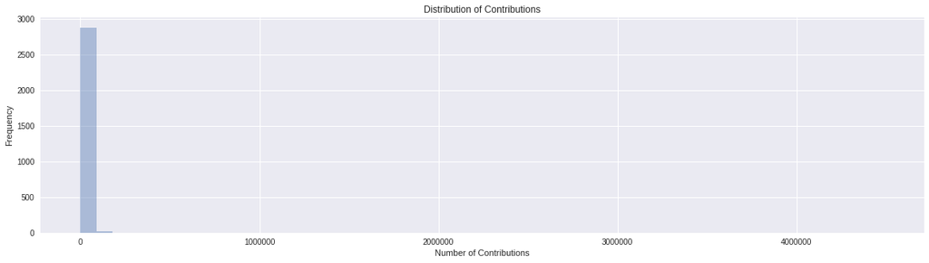

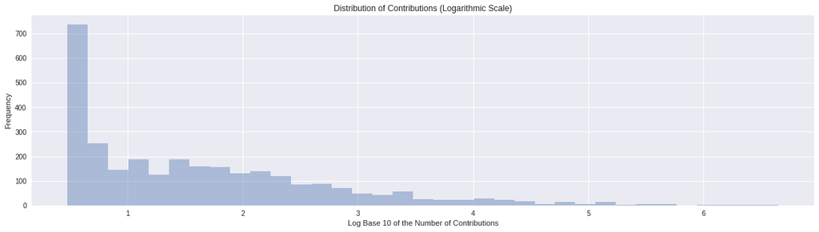

```python
# Now, we'll plot the data. First, we'll plot the raw data.
#  Next, we'll plot the logarithm of the contributions, as
#  the prior aggregation indicated that the data may be very
#  strongly skewed.

plt.figure(figsize=(20,5))
sns.distplot(data, kde=False)
plt.xlabel("Number of Contributions")
plt.ylabel("Frequency")
plt.title("Distribution of Contributions")
plt.show()

plt.figure(figsize=(20,5))
sns.distplot(np.log10(data), bins=35, kde=False)
plt.xlabel("Log Base 10 of the Number of Contributions")
plt.ylabel("Frequency")
plt.title("Distribution of Contributions (Logarithmic Scale)")
plt.show()
```

This is reminiscent of the Pareto principle (i.e., the 80/20 rule, which states that 80% of the effects come from 20% of the population). Let us look, then, at the ratio of users relative to the ratio of total contributions made by said users.

```python
# Calculate the ratios of contributions. Using the existing data
#  list saves time. The list is sorted in descending order of
#  number of contributions made.
ratios = [np.sum(data[:i])/np.sum(data) for i in range(len(data))]
```

```python
# The following finds the number of distinct users, which we'll
#  need for our calculations
len(sfc.distinct('created.user'))
```

```
2912
```

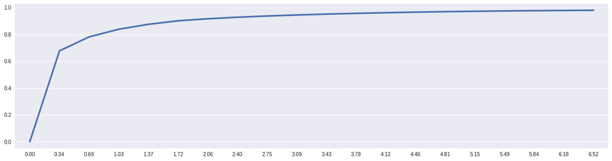

```python
# Plot the ratios of users relative to the ratios of total contributions
#  made by said users. We'll go by intervals of 10 so as to save computational
#  resources and aid readability. It does not seem likely that smaller intervals
#  (e.g., of size 1) are necessary
plt.figure(figsize=(20,5))
sns.pointplot(x=['{:.2f}'.format(100 * i/2912) for i in range(0,200,10)],
              y=ratios[:200:10], markers='')
plt.show()
```

Let's get a raw numerical representation of the ratios

```python
ratios[:350:10]
```

```
[0.0,
 0.67684077311855084,
 0.78099990841858169,
 0.83822008567950468,
 0.8749707448247126,
 0.90093354134633252,
 0.916012207642389,
 0.92759136585384139,
 0.93682408494899561,
 0.9443384474325337,
 0.95084206704081153,
 0.95637484328062849,
 0.96121366266225572,
 0.96545532835151837,
 0.96904186556169136,
 0.97192480576438078,
 0.97435653342373651,
 0.97635592716545871,
 0.97796382373308355,
 0.97934102617246976,
 0.98061687315330892,
 0.9817848040184427,
 0.98287842539943693,
 0.98388742769218573,
 0.98485090705771394,
 0.98573445351868128,
 0.98653083696311727,
 0.98725103644994006,
 0.98791634064217315,
 0.98851322655261298,
 0.98905334269498946,
 0.98955623714981489,
 0.99001615260570552,
 0.99043978361078222,
 0.99083382471316539]
```

```python
320 / len(data)
```

```
0.10985238585650532
```

```python
# The following finds all of the 'pos' values in the database
result = list(sfc.find({}, {'pos' : 1, '_id' : 0}))

# Append all lists of coordinates
coordinates = np.array([])
for coords in result:
    if coords:
        coordinates.append(coords['pos'])
```

```python
# Let us check to see if our any of our coordinates are blatantly incorrect
latitudes = np.array([l[0] for l in coordinates])
longitutdes = np.array([l[1] for l in coordinates])

print('latitudes below 37: {}'.format(sum(latitudes < 37)))
print('latitudes above 38: {}'.format(sum(latitudes > 38)))
print('longitudes below -123: {}'.format(sum(longitutdes < -123)))
print('longitudes above -122: {}'.format(sum(longitutdes > -122)))
```

[output not shown]

Now, let's cluster our geographic coordinates and see how well, relatively speaking, each region is represented. In order to determine regions, we'll cluster the coordinates.

Before we begin, we want to make sure that a significant enough portion of the elements include a "pos" attribute.

```python
sfc.find({"pos" : {"$exists" : 1}}).count()
```

```
19923105
```

```python
sfc.find().count()
```

```
22406292
```

Wonderful. 19.9e6 out of 22.4e6 seems pretty substantial. Now let's begin with clustering. We'll use the kmeans2 and whiten functions from the scipy.cluster.vq module. We'll first use the whiten function to normalize our points, which should theoretically improve our clustering accuracy. For our purposes, a high degree of spatial resolution doesn't seem necessary so we'll use 5 clusters as it seems reasonable to separate the Bay Area into 5 regions (there's the region north of the Golden Gate Bridge, the area in the near vicinity of San Francisco, the area south of that, the East Bay Area, and the area north of that) and we'll run 25 iterations of clustering. If the data is not strongly skewed, it should not be unreasonable to expect 5 centroids to be found. The resulting centroids will be stored in `centroids` and the labels will be stored in `labels`.

```python
centroids, labels = kmeans2(whiten(coordinates), 5, iter=25)
```

The below graph shows how our raw coordinates appear on a map and will serve as a point of reference. Considering the curvature of the planet, the plot seems reasonable.

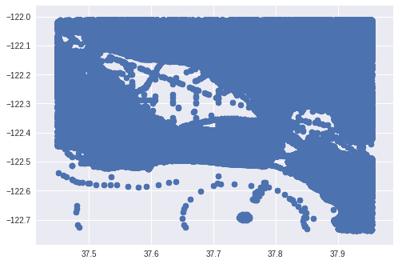

```python
plt.scatter(x=coordinates[:,0], y=coordinates[:,1])
plt.show()
```

Now let's look at our points as pertaining to the clusters we found. First, we'll see if the centroids seem reasonable given what we know of the region. We'll also use a small alpha level so that we can visually assess density and decide how to proceed in the future if necessary.

We can also take this opportunity to estimate the reasonableness of representation. To be fair, clustering will be formed so long as there are different areas reported. If the cluster locations don't agree with our knowledge of the region, we can conclude that K means clustering did not work well for our purposes and the regions in our data are not well represented (e.g., there may be pockets of active users in relatively featureless locations that are distributed randomly).

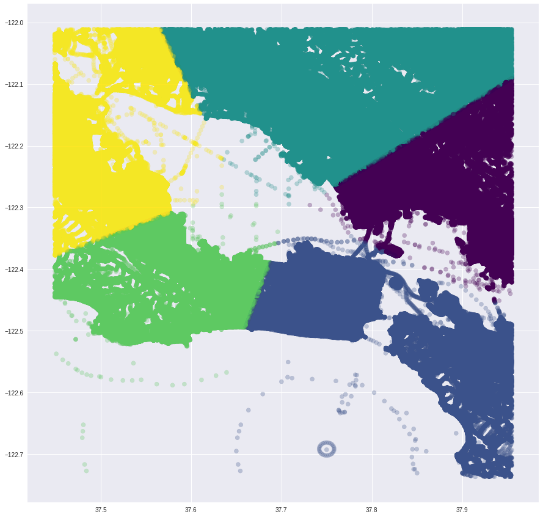

```python
plt.figure(figsize=(15,15))
plt.scatter(x=coordinates[:,0], y=coordinates[:,1],
            alpha=.1, c=labels, cmap='viridis')
plt.show()
```

The plot seems reasonable. We clearly see five regions as one might expect based on distribution of activity and of the general population, as opposed to a random distribution - the northeast and northwestern regions of the Bay Area, which are relatively sparse, the region in the near vicinity of San Francisco, the East Bay Area, the southwestern area, such as around Palo Alto and Sunnyvale, and the southeastern area, such as around Fremont and San Jose. Further, each region seems well represented, as is shown by visibility despite the lower alpha level of 0.1.

In case visual inspection of a spatial plot isn't sufficient, we'll also look at the raw numbers. We can simply look at the number of each label.

```python
pd.Series(labels).value_counts()
```

```
1    6286485
2    4441062
0    3729426
4    3048366
3    2417766
dtype: int64
```

The distribution does not seem unreasonable. A degree of variation is to be expected, as some areas are more dense and metropolitan, with more points of interests and a larger population. The cluster with label 1 is more than twice as well represented as the cluster with label 3, but the disparity is not too substantial. Of course the disparity would be larger with a stipulation that more clusters be formed, but such a stipulation does not seem warranted.

Now, let's examine the regional distribution of amenities. In this case, we'll define a region by a city

```python
# There are many cities in this dataset and less well represented
#  cities will probably not have an informative number of corresponding
#  elements so we will only consider the three cities with the most
#  corresponding elements. Let's find these three cities.

# First we need to find all of the unique cities. For our aggregation query,
#  we'll use a pipeline in which we first filter for all elements that
#  specify a city. Then, we'll group by the city name, count up the groups, and sort
#  the groups by count.
stage1 = {'$match' : {'address.city' : {'$exists' : 1}}}
stage2 = {'$group' : {'_id' : '$address.city', 'count' : {'$sum' : 1}}}
stage3 = {'$sort' : {'count' : -1}}

# Get the first three results in the query
cities_dictionary = list(sfc.aggregate([stage1, stage2, stage3, {'$limit' : 3}]))

# Extract the city names from the resulting list
cities = []
for city in cities_dictionary:
    cities.append(city['_id'])

# We'll modify the first stage of the pipeline based on the city name at hand, but
#  the other stages of the pipeline need not change. Once we filter for elements
#  with a corresponding city name, we'll group the elements by amenity
#  type, enumerate the groups, then sort the result.
stage2 = {'$group' :
          {'_id' : {'amenity' : '$amenity'},
          'count' : {'$sum' : 1}}
         }

stage3 = {'$sort' : {'count' : -1}}

# Construct a stage based on the above cities and construct a pipeline from
#  the above stages and view the results of the queries. We'll also limit
#  the size of the result set so it is more manageable.
for city in cities:
    print('-------------------\nCity: {}\n-------------------'.format(city))
    stage1 = {'$match' :
              {'address.city' : city, 'amenity' : {'$exists' : 1}}
             }
    result = list(sfc.aggregate([stage1, stage2, stage3, {'$limit' : 6}]))
    pprint.pprint(result)
    print('-------------------')
```

```
-------------------
City: Redwood City
-------------------
[{'_id': {'amenity': 'restaurant'}, 'count': 279},
 {'_id': {'amenity': 'fast_food'}, 'count': 63},
 {'_id': {'amenity': 'cafe'}, 'count': 42},
 {'_id': {'amenity': 'bank'}, 'count': 42},
 {'_id': {'amenity': 'place_of_worship'}, 'count': 33},
 {'_id': {'amenity': 'parking'}, 'count': 27}]
-------------------
-------------------
City: San Francisco
-------------------
[{'_id': {'amenity': 'restaurant'}, 'count': 1971},
 {'_id': {'amenity': 'cafe'}, 'count': 678},
 {'_id': {'amenity': 'bar'}, 'count': 303},
 {'_id': {'amenity': 'bank'}, 'count': 252},
 {'_id': {'amenity': 'school'}, 'count': 204},
 {'_id': {'amenity': 'place_of_worship'}, 'count': 195}]
-------------------
-------------------
City: Berkeley
-------------------
[{'_id': {'amenity': 'restaurant'}, 'count': 408},
 {'_id': {'amenity': 'parking'}, 'count': 183},
 {'_id': {'amenity': 'cafe'}, 'count': 138},
 {'_id': {'amenity': 'school'}, 'count': 90},
 {'_id': {'amenity': 'place_of_worship'}, 'count': 81},
 {'_id': {'amenity': 'fast_food'}, 'count': 60}]
-------------------
```

For the sake of comparison, let's expand our domain to include the entire dataset.

```python
# Show what amenities are most represented. We'll need a pipeline. First,
#  let's make sure filter for elements labelled as amenities. Next, we'll
#  group by amenity type and then sort the result set by the counts obtained
stage1 = {'$match' : {'amenity' : {'$exists' : 1}}}
stage2 = {'$group' :
          {'_id' : {'amenity' : '$amenity'},
          'count' : {'$sum' : 1}}
         }

stage3 = {'$sort' : {'city' : -1, 'amenity' : -1, 'count' : -1}}

# Construct a stage based on the above cities and view the results. We'll
#  also limit the size of the result set so it is more manageable.
pprint.pprint(list(sfc.aggregate([stage1, stage2, stage3, {'$limit' : 6}])))
```

```
[{'_id': {'amenity': 'parking'}, 'count': 13869},
 {'_id': {'amenity': 'restaurant'}, 'count': 10263},
 {'_id': {'amenity': 'bench'}, 'count': 3951},
 {'_id': {'amenity': 'school'}, 'count': 3825},
 {'_id': {'amenity': 'place_of_worship'}, 'count': 3525},
 {'_id': {'amenity': 'cafe'}, 'count': 3291}]
```

It seems that restaurants, bars, banks, cafes, and places of worship are the most common amenities in three of the most seemingly popular cities. Restaurants seem to be, consistently, the most common (aside from 'parking' in the overall dataset) whereas places of worship are consistently in the top 5 or 6. Oddly, the prevalence of banks seems far less consistent, as banks are the fourth most commonly reported amenity in Redwood City but didn't make the top 6 for Berkeley.

Let's look more closely at these three and see what the most commonly reported restaurants, banks, and religious establishments are.

```python
# We need to construct stages for the pipeline. We must filter for
#  elements that are amenities, have a name, and are a restaurant.
#  Then, we must group the elements by name, count the groups,
#  and sort the results by count.
stage1 = {'$match' :
          {'amenity' : {'$exists' : 1}, 'amenity' : 'restaurant',
           'name' : {'$exists' : 1}}
         }
stage2 = {'$group' : {'_id' : '$name', 'count' : {'$sum' : 1}}}
stage3 = {'$sort' : {'count' : -1}}

# Construct a stage based on the above cities and construct a pipeline
#  from the above stages and view the results of the queries. We'll also
#  limit the size of the result set so it is more manageable.
result = list(sfc.aggregate([stage1, stage2, stage3, {'$limit' : 20}]))
pprint.pprint(result)
```

```
[{'_id': 'En', 'count': 129},
 {'_id': 'Zh', 'count': 51},
 {'_id': 'Round Table Pizza', 'count': 39},
 {'_id': 'Subway', 'count': 39},
 {'_id': 'IHOP', 'count': 30},
 {'_id': 'Chipotle', 'count': 27},
 {'_id': "Denny's", 'count': 24},
 {'_id': 'Panera Bread', 'count': 18},
 {'_id': 'Pizza Hut', 'count': 15},
 {'_id': 'Pasta Pomodoro', 'count': 15},
 {'_id': 'Gordo Taqueria', 'count': 15},
 {'_id': 'Pacific Catch', 'count': 15},
 {'_id': "Applebee's", 'count': 15},
 {'_id': 'California Pizza Kitchen', 'count': 15},
 {'_id': 'Squat & Gobble', 'count': 12},
 {'_id': 'Oasis Grill', 'count': 12},
 {'_id': "Mountain Mike's", 'count': 12},
 {'_id': 'North Beach Pizza', 'count': 12},
 {'_id': "Rubio's", 'count': 12},
 {'_id': "Henry's Hunan Restaurant", 'count': 12}]
```

It seems several institutions, such as "En" and "Zh" (perhaps catch-alls for English and Chinese restaurants, respectively), were either named incorrectly or only vaguely. The eateries listed appear to be mostly fast food establishments or places to get a quick bite to eat, as opposed to traditional sit-down restaurants, which are still present but at much lower frequencies. Perhaps this is a shortcoming of the data collection process or perhaps this is an issue worth notice.

Let's move on to banks.

```python
# We need to construct stages for the pipeline. We must filter
#  for elements that are amenities, have a name, and are a bank.
#  Then, we must group the elements by name, count the groups,
#  and sort the results by count.
stage1 = {'$match' :
          {'amenity' : {'$exists' : 1}, 'amenity' : 'bank',
           'operator' : {'$exists' : 1}}
         }
stage2 = {'$group' : {'_id' : '$operator', 'count' : {'$sum' : 1}}}
stage3 = {'$sort' : {'count' : -1}}

# Construct a stage based on the above cities and construct a
#  pipeline from the above stages and view the results of the queries.
#  We'll also limit the size of the result set so it is more manageable.
result = list(sfc.aggregate([stage1, stage2, stage3, {'$limit' : 20}]))
pprint.pprint(result)
```

```
[{'_id': 'Wells Fargo', 'count': 42},
 {'_id': 'Bank of America', 'count': 33},
 {'_id': 'Chase', 'count': 18},
 {'_id': 'Citibank', 'count': 12},
 {'_id': 'Citi Bank', 'count': 9},
 {'_id': 'First National Bank of Northern California', 'count': 9},
 {'_id': 'US Bank', 'count': 6},
 {'_id': 'First Republic Bank', 'count': 6},
 {'_id': 'East West Bank', 'count': 6},
 {'_id': 'Chase Bank', 'count': 6},
 {'_id': 'Bank of the Orient', 'count': 3},
 {'_id': 'Fremont Bank', 'count': 3},
 {'_id': 'Far East National Bank', 'count': 3},
 {'_id': 'Wells Fargo Bank', 'count': 3},
 {'_id': 'WestAmerica Bank', 'count': 3},
 {'_id': 'Bank of Americ', 'count': 3},
 {'_id': 'Bank of the West', 'count': 3},
 {'_id': 'Chase Manhattan', 'count': 3},
 {'_id': 'Union Bank', 'count': 3},
 {'_id': 'HSBC Bank', 'count': 3}]
```

This time, we don'tsee "En", which may be an incorrect or a vague name. Citibank appears less common than Chase but if alternative are accounted for (i.e., 'Citi Bank'), this bank is actually more common than Chase. The difference disappears if you also consider "Chase Bank," "Chase Manhattan," and "Chase" to represent the same entity. Bank of America also has a somewhat common mispelling - "Bank of Americ". All of this goes to show that the data collection process is in need of quality standards.

Let's move on to places of worship.

```python
# We need to construct stages for the pipeline. We must filter
#  for elements that are amenities, have a name, and are
#  a bank. Then, we must group the elements by name,
#  count the groups, and sort the results by count.
stage1 = {'$match' :
          {'amenity' : {'$exists' : 1},
           'amenity' : 'place_of_worship',
           'religion' : {'$exists' : 1}}
         }
stage2 = {'$group' : {'_id' : '$religion', 'count' : {'$sum' : 1}}}
stage3 = {'$sort' : {'count' : -1}}

# Construct a stage based on the above cities and construct
#  a pipeline from the above stages and view the results
#  of the queries. We'll also limit the size of the result
#  set so it is more manageable.
result = list(sfc.aggregate([stage1, stage2, stage3, {'$limit' : 20}]))
pprint.pprint(result)
```

```
[{'_id': 'christian', 'count': 3063},
 {'_id': 'buddhist', 'count': 126},
 {'_id': 'jewish', 'count': 57},
 {'_id': 'muslim', 'count': 30},
 {'_id': 'unitarian_universalist', 'count': 12},
 {'_id': 'taoist', 'count': 9},
 {'_id': 'hindu', 'count': 9},
 {'_id': 'perfect_liberty', 'count': 6},
 {'_id': 'scientologist', 'count': 6},
 {'_id': 'humanist', 'count': 3},
 {'_id': 'eckankar', 'count': 3},
 {'_id': 'shinto', 'count': 3},
 {'_id': 'spiritualist', 'count': 3},
 {'_id': 'bahai', 'count': 3}]
```

The vast majority of places of worship are categorized as being Christian establishments. Coming in second, a mere 4% as many establishments are classified as Buddhist. The four most common religious establishments are in keeping with my expectations regarding the country. Unlike banks, religions don't seem commonly mispelled. Further conclusions refer to personal biases so let's end here.

## Conclusions and Other Ideas About the Dataset

We specifically examined OpenStreetMap data corresponding to a dataset labelled on Metro Extracts as San Francisco, CA. The data was bounded by a rectangular region, as in the line `<bounds minlat="37.449" minlon="-122.737" maxlat="37.955" maxlon="-122.011"/>`. The dataset was quite large (1.414 GB as an uncompressed XML) and unlikely to work with our memory constraints, so a MongoDB database was used. To load the data into a MongoDB database, though, we had to convert the file to a JSON format.

In the process, we addressed potentially mispelled street types and data that cannot be included in a MongoDB database. The data finally consisted of a list of dictionaries, which conformed to the JSON format and were stored in a separate file approximately 2.0 GB in size.

We then proceeded to examine the data with the help of MongoDB. We found that:

### Other Ideas About the Dataset

It is encouraging to see that the different portions of the area studied appear well represented. For the time being, it appears business decisions may be shaped, in part, by this data.

In the future, alternative spellings may be made more consistent and more far-reaching conclusions can be drawn about the prevalence of certain establishments. Further, discontinued establishments (e.g., a store that closed) may be flagged for removal and subsequently removed from the dataset. Users could report on the continuity of establishments and infrastructure.

Considering the success of Wikipedia, similar ideas could be adopted for the OpenStreetMaps dataset. Data could be made more easily evaluated for accuracy by other users and users could be allowed to edit contributions of other users. With regard to editing, a system of repute and/or credibility could be established to ensure that data is more likely to be improved in terms of accuracy than to be corrupted by pranksters. Alternatively or in addition, edits could be required to be checked by other a particular number parties, such as other users.

It is possible that even with such an advent, the room for inaccuracies, such as from dishonest tampering, may still be too great. For instance, an incredible trove of expert-level information may be found on Wikipedia, and inaccuracies, while not very prevalent, still exist. It remains to be seen, though, whether an analog of such inaccuracies in OpenStreetMaps is acceptable.

It may also be advisable to make contributing an easier process. As it stands, the number of contributors may not be inspiring - we found less than 3,000 unique users contributed to this particular dataset, which does not compare well with the population of 7 million people in the Bay Area ([source](http://www.bayareacensus.ca.gov/)). Even if you assume that over half of the population is too busy, too young or too old to either think at a sufficiently advanced level or operate a computing device, or unable to contribute anything of value, there still remains a large, untapped base of potential users.

This suggests that the process of contributing is excessively unpalatable. If the process is too difficult (e.g., requiring one to peruse a lengthy beginner's tutorial) and/or time consuming, such should be addressed. For instance, the prevalence of smartphones could be taken advantage of. Data contribution could be made far easier by means of a smartphone application and users could opt to have their smartphones automatically provide information, thereby providing further details such as population density and the degree to which a road is utilized or an establishment is frequented, among other details.

In addition, incentives may be provided for contributing data. The use of reCAPTCHA to collect data for the digitization of books comes to mind. The existence of a such a necessary yet simple task that could serve as an avenue for the collection of data for OpenStreetMaps is not intuitive. Perhaps we will never find a scenario as convenient as distinguishing human activity from automated activity (i.e., that which reCAPTCHA capitalizes on), but it is possible that a source of incentives (e.g., the provision of personal satisfaction) could be discovered and utilized to further the complexity and accuracy of OpenStreetMap data.

As a result of these efforts, it is possible that the results of the analysis may be different after such is done. It is possible that more reliable and complex business decisions could be made on the basis of analyses of this dataset. These anticipated issues and potential benefits should be analyzed by influential parties.